# Covid & Kinsa Analysis

Thomas Zhao

04/24/2020

## Guiding Question

Can we make predictions and/or find useful correlations in Covid data using [Kinsa’s](https://www.kinsahealth.co/enterprise/kinsa-insights/) health data?

### Data source #1

Who: New York Times

What: data on coronavirus cases and deaths in the U.S.

Where: the U.S.

When: 01/21/2020 to Present

Why: The Times maintain this dataset in an attempt to provide a complete record of the ongoing outbreak

The New York Times maintains a handy [Github repo](https://github.com/nytimes/covid-19-data) of the most recent data regarding Covid-19. Within are two csv files which contain data on Covid-19 cases at the county-level & state-level. We’ll be focusing on county-level data (where each case represents a Covid cases in a county on a given date) since our other data source is county-level as well.

Below, we load the most recent nytimes data directly from their Github.

```r
library("RCurl")
x <- getURL("https://raw.githubusercontent.com/nytimes/covid-19-data/master/us-counties.csv")
Covid <- read.csv(text = x, header=TRUE)
head(Covid)
```

|  | date | county | state | fips | cases | deaths |
| --- | --- | --- | --- | --- | --- | --- |
| 1 | 2020-01-21 | Snohomish | Washington | 53061 | 1 | 0 |
| 2 | 2020-01-22 | Snohomish | Washington | 53061 | 1 | 0 |
| 3 | 2020-01-23 | Snohomish | Washington | 53061 | 1 | 0 |
| 4 | 2020-01-24 | Cook | Illinois | 17031 | 1 | 0 |
| 5 | 2020-01-24 | Snohomish | Washington | 53061 | 1 | 0 |
| 6 | 2020-01-25 | Orange | California | 6059 | 1 | 0 |

```r
str(Covid)
```

```
'data.frame':   89772 obs. of  6 variables:
 $ date  : Factor w/ 96 levels "2020-01-21","2020-01-22",..: 1 2 3 4 4 5 5 5 6 6 ...
 $ county: Factor w/ 1673 levels "Abbeville","Acadia",..: 1383 1383 1383 363 1383 1117 363 1383 925 888 ...
 $ state : Factor w/ 55 levels "Alabama","Alaska",..: 52 52 52 15 52 5 15 52 3 5 ...
 $ fips  : int  53061 53061 53061 17031 53061 6059 17031 53061 4013 6037 ...
 $ cases : int  1 1 1 1 1 1 1 1 1 1 ...
 $ deaths: int  0 0 0 0 0 0 0 0 0 0 ...
```

```r
nrow(Covid)
```

```
[1] 89772
```

As of 4/26/2020, we have 89772 cases in the data frame, where each case is an observation of the # of Covid cases on a given day in a county. Interestingly, there are apparently 55 “states” in this dataset according to the ‘state’ factor from the str() function. Let’s examine this before moving on.

```r
levels(Covid$state)
```

```
 [1] "Alabama"                  "Alaska"                   "Arizona"                  "Arkansas"
 [5] "California"               "Colorado"                 "Connecticut"              "Delaware"
 [9] "District of Columbia"     "Florida"                  "Georgia"                  "Guam"
[13] "Hawaii"                   "Idaho"                    "Illinois"                 "Indiana"
[17] "Iowa"                     "Kansas"                   "Kentucky"                 "Louisiana"
[21] "Maine"                    "Maryland"                 "Massachusetts"            "Michigan"
[25] "Minnesota"                "Mississippi"              "Missouri"                 "Montana"
[29] "Nebraska"                 "Nevada"                   "New Hampshire"            "New Jersey"
[33] "New Mexico"               "New York"                 "North Carolina"           "North Dakota"
[37] "Northern Mariana Islands" "Ohio"                     "Oklahoma"                 "Oregon"
[41] "Pennsylvania"             "Puerto Rico"              "Rhode Island"             "South Carolina"
[45] "South Dakota"             "Tennessee"                "Texas"                    "Utah"
[49] "Vermont"                  "Virgin Islands"           "Virginia"                 "Washington"
[53] "West Virginia"            "Wisconsin"                "Wyoming"
```

In addition to the 50 states, we see that this dataset also includes 4 territories + D.C.

### Data source #2

Who: [Kinsa](https://www.kinsahealth.co/)

What: data on influenza-like incidents (ili) aggregated from Kinsa’s smart thermometers

Where: the U.S.

When: 02/16/2020 to Present

Why: To track (and possibly predict) the spread of contagious illnesses

Our second source of data is Kinsa’s public health API, which aggregates data from Kinsa’s [smart thermometers](https://www.kinsahealth.co/products/#buynow). The API base url is “https://static.kinsahealth.com”. Details on how the data was extracted from the API can be found in the Python file in this repository.

Let’s have a look at the Kinsa data

```r
KinsaData <- read.csv("kinsa_county.csv")
head(KinsaData)
```

|  | region_id | region_name | state | date | doy | observed_ili | atypical_ili | anomaly_diff | forecast_expected | forecast_lower | forecast_upper |
| --- | --- | --- | --- | --- | --- | --- | --- | --- | --- | --- | --- |
| 1 | 1031 | Coffee County | AL | 2020-02-16 | 47 | 4.497530 | NA | 0 | NA | NA | NA |
| 2 | 1029 | Cleburne County | AL | 2020-02-16 | 47 | 5.135954 | NA | NA | NA | NA | NA |
| 3 | 1029 | Cleburne County | AL | 2020-02-16 | 47 | 5.135954 | NA | NA | NA | NA | NA |
| 4 | 1085 | Lowndes County | AL | 2020-02-16 | 47 | 5.068342 | NA | NA | NA | NA | NA |
| 5 | 1085 | Lowndes County | AL | 2020-02-16 | 47 | 5.068342 | NA | 0 | NA | NA | NA |
| 6 | 1089 | Madison County | AL | 2020-02-16 | 47 | 4.850512 | NA | 0 | NA | NA | NA |

```r
str(KinsaData)
```

```
'data.frame':   412335 obs. of  11 variables:
 $ region_id        : int  1031 1029 1029 1085 1085 1089 1089 1035 1035 1087 ...
 $ region_name      : Factor w/ 1843 levels "Abbeville County",..: 366 352 352 991 991 1009 1009 389 389 1006 ...
 $ state            : Factor w/ 49 levels "AL","AR","AZ",..: 1 1 1 1 1 1 1 1 1 1 ...
 $ date             : Factor w/ 99 levels "2020-02-16","2020-02-17",..: 1 1 1 1 1 1 1 1 1 1 ...
 $ doy              : int  47 47 47 47 47 47 47 47 47 47 ...
 $ observed_ili     : num  4.5 5.14 5.14 5.07 5.07 ...
 $ atypical_ili     : num  NA NA NA NA NA NA NA NA NA NA ...
 $ anomaly_diff     : num  0 NA NA NA 0 0 0 NA NA NA ...
 $ forecast_expected: num  NA NA NA NA NA NA NA NA NA NA ...
 $ forecast_lower   : num  NA NA NA NA NA NA NA NA NA NA ...
 $ forecast_upper   : num  NA NA NA NA NA NA NA NA NA NA ...
```

```r
nrow(KinsaData)
```

```
[1] 412335
```

Just like the Covid data, each case represents observations in a county on a given data. In this case, the observation is “observed_ili,” which is the observed influenza-like illness (ili) rate which Kinsa aggregates from all its thermometers. Kinsa also provides other useful variables, such as forecast_expected, which is the expected (historical) ili rate in that county, and anomaly_diff, which is the difference between the observed_ili and forecast_expected. We will be focusing on anomaly_diff and observed_ili mainly.

For more info on the details of these variables, see here: https://content.kinsahealth.com/covid-detection-technical-approach

Note that we have significantly more cases in Kinsa data than Covid. We will have to filter for only counties affected by Covid later.

## EDA

First we need to reformat some of the data to have proper data types. Then we prepare for a join to eliminate Kinsa data in counties unaffected by Covid.

```r
Covid <- Covid %>%
  mutate(date = ymd(date))
KinsaData <- KinsaData %>%
  mutate(date = ymd(date)) %>%
  select(region_id, region_name, date, observed_ili, anomaly_diff)
CovidKinsa <- Covid %>%
  left_join(KinsaData, by = c("fips" = "region_id", "date" = "date"))
head(CovidKinsa)
```

|  | date | county | state | fips | cases | deaths | region_name | observed_ili | anomaly_diff |
| --- | --- | --- | --- | --- | --- | --- | --- | --- | --- |
| 1 | 2020-01-21 | Snohomish | Washington | 53061 | 1 | 0 | NA | NA | NA |
| 2 | 2020-01-22 | Snohomish | Washington | 53061 | 1 | 0 | NA | NA | NA |
| 3 | 2020-01-23 | Snohomish | Washington | 53061 | 1 | 0 | NA | NA | NA |
| 4 | 2020-01-24 | Cook | Illinois | 17031 | 1 | 0 | NA | NA | NA |
| 5 | 2020-01-24 | Snohomish | Washington | 53061 | 1 | 0 | NA | NA | NA |
| 6 | 2020-01-25 | Orange | California | 6059 | 1 | 0 | NA | NA | NA |

Note that Kinsa data starts after 2/16/2020, so some NAs are expected. Let’s find out which counties have been affected as of 4-22-2020 most so we know where to focus.

```r
CovidKinsa %>%
  filter(date == mdy("4-22-2020")) %>%
  mutate(covid_rank = rank(cases)) %>%
  arrange(desc(covid_rank)) %>%
  head(10)
```

|  | date | county | state | fips | cases | deaths | region_name | observed_ili | anomaly_diff | covid_rank |
| --- | --- | --- | --- | --- | --- | --- | --- | --- | --- | --- |
| 1 | 2020-04-22 | New York City | New York | NA | 142442 | 10614 | NA | NA | NA | 3740.0 |
| 2 | 2020-04-22 | Nassau | New York | 36059 | 31555 | 1764 | Nassau County | NA | 0 | 3739.0 |
| 3 | 2020-04-22 | Suffolk | New York | 36103 | 28854 | 959 | Suffolk County | NA | 0 | 3738.0 |
| 4 | 2020-04-22 | Westchester | New York | 36119 | 25275 | 932 | Westchester County | NA | 0 | 3737.0 |
| 5 | 2020-04-22 | Cook | Illinois | 17031 | 24546 | 1072 | Cook County | NA | 0 | 3736.0 |
| 6 | 2020-04-22 | Los Angeles | California | 6037 | 16435 | 729 | Los Angeles County | NA | NA | 3734.5 |
| 7 | 2020-04-22 | Los Angeles | California | 6037 | 16435 | 729 | Los Angeles County | NA | 0 | 3734.5 |
| 8 | 2020-04-22 | Wayne | Michigan | 26163 | 14561 | 1319 | Wayne County | NA | 0 | 3733.0 |
| 9 | 2020-04-22 | Bergen | New Jersey | 34003 | 13686 | 876 | Bergen County | NA | 0 | 3732.0 |
| 10 | 2020-04-22 | Hudson | New Jersey | 34017 | 12039 | 568 | Hudson County | NA | 0 | 3731.0 |

Counties in New York take up nearly half of the top 10!

To get a feel for the data, let’s compare Covid cases in New York City, a highly affected city, and Seattle (King County) one of the earliest cities to get Covid:

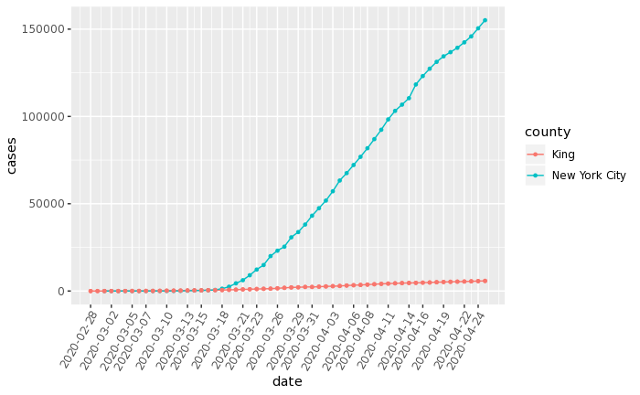

```r
cases_NYC_Seattle <- CovidKinsa %>%
  filter(state == "New York" | state == "Washington") %>%
  filter(county == "New York City" | county == "King")
ggplot(data = cases_NYC_Seattle, aes(x = date, y = cases, group=county)) + geom_line(aes(color=county)) + geom_point(aes(color=county), size=1) +
scale_x_date(breaks = cases_NYC_Seattle$date[seq(1, length(cases_NYC_Seattle$date), by = 8)]) + theme(axis.text.x = element_text(angle = 60, hjust = 1))
```

Wow, cases in NYC really took off in Mid-March, making Seattle’s curve look almost flat!

This is consistent with the news so far. Now let’s examine the Kinsa data for New York County aka Manhattan (Kinsa only includes county level data) in relation to Covid cases.

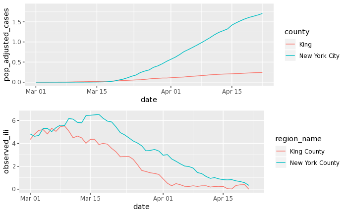

```r
#Note: For NYC's Kinsa data, we don't use the joined dataset because New York City is a unique case in the NYtimes dataset (NYC is really made up of several counties, causing the county-level join by region_id to fail).
Kinsa_NYC_Seattle <- KinsaData %>%
  filter(region_id == 36061 | region_id == 53033) #Instead we use New York County (the first region_id) to best represent NYC
#We also normalize the Covid data to look at a percentage of population, via an ifelse() transformation
cases_NYC_Seattle <- cases_NYC_Seattle %>%
  #King County has around 2.3 million residents, versus NYC's 8.3 million
  mutate(pop_adjusted_cases = ifelse(county == "King", cases/2252782 * 100, cases/8336817 * 100))
require(gridExtra)
plot1 <- ggplot(data=cases_NYC_Seattle, aes(x = date, y = pop_adjusted_cases, group=county)) + geom_line(aes(color=county)) +
        xlim(mdy("3/1/2020"), mdy("4/22/2020"))
plot2 <- ggplot(data=Kinsa_NYC_Seattle, aes(x = date, y = observed_ili, group=region_name)) +
        geom_line(aes(color=region_name)) +
        xlim(mdy("3/1/2020"), mdy("4/22/2020"))
grid.arrange(plot1, plot2, ncol=1)
```

This looks promising; we see that observed_ili peaks right before when the Covid cases start being registered. The peak for Seattle is before New York’s, which makes sense as Seattle was one of the earlier cities to have an outbreak.

Perhaps observed_ili can be an effective predictor of outbreak, but let’s also take a look at the distribution of instances where anomaly_diff is not N/A (meaning Kinsa has detected an anomalous rate of influenza-like activity).

First we define a function to help us make anomaly_diff more plot-able.

```r
#This function iterates through a vector, replacing zeroes with NA (to avoid plotting them) and the rest to a given constant (we are only interested in the presence of an anomaly, and the constant lets us adjust the height on the plot)
constant_or_NA <- function(vec, constant) {
    for (i in c(1:length(vec))) {
      if (is.na(vec[i]) | vec[i] == 0) {
        vec[i] <- NA
      } else {
        vec[i] <- constant
      }
    }

  return(vec)
}
```

Then we overlay dots over days with anomalous activity.

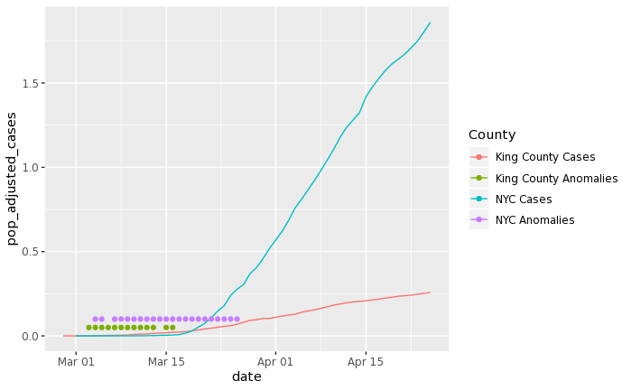

```r
Kinsa_NYC <- Kinsa_NYC_Seattle %>%
  filter(region_id == 36061 & date >= mdy("2/28/2020") & date <= mdy("4/21/2020")) #only getting dates where we have Covid data
Kinsa_Seattle <- Kinsa_NYC_Seattle %>%
  filter(region_id == 53033 & date >= mdy("2/28/2020") & date <= mdy("4/21/2020"))
Kinsa_Seattle <- Kinsa_Seattle[complete.cases(Kinsa_Seattle), ] #Seattle data had some duplicate rows with NA, so we get rid of them. Doesn't affect the visualizations though.
Kinsa_NYC$anomaly_diff <- constant_or_NA(Kinsa_NYC$anomaly_diff, 0.1)
Kinsa_Seattle$anomaly_diff <- constant_or_NA(Kinsa_Seattle$anomaly_diff, 0.05)
ggplot(data = cases_NYC_Seattle, aes(x = date, y = pop_adjusted_cases)) +
        geom_line(aes(color = county)) +
        geom_point(data = Kinsa_NYC, aes(x = date, y = anomaly_diff, color=region_name)) +
        geom_point(data = Kinsa_Seattle, aes(x = date, y = anomaly_diff, color=region_name)) +
        scale_color_hue(name = "County", labels = c("King County Cases", "King County Anomalies", "NYC Cases", "NYC Anomalies"))
```

Compared with Seattle, New York has a much longer period of anomalous activity, which makes sense given true extent of the outbreak in NYC. In either case, there is substantial anomalous activity in the days leading up to the “explosion” in Covid cases.

### Some Statistical Analysis

We now turn our attention to Seattle, which was one of the first places to be affected by Covid-19, and is a bit easier to work with data-wise since the city isn’t split into multiple counties like NYC.

```r
View(Kinsa_Seattle) #confirming the data looks good
```

We want to know if observed_ili has any sort of predictive power regarding Covid-19 cases. To do this, we will run the cross correlation function (ccf) on the two time series ‘cases’ and ‘observed_ili’ from 02/28/2020 to 4/21/2020.

Extracting the relevant time series

```r
kinsa  <- Kinsa_Seattle$observed_ili
Cases_Seattle <- cases_NYC_Seattle %>%
                    filter(county == "King")
Cases_Seattle <- Cases_Seattle[complete.cases(Cases_Seattle), ]
cases <- Cases_Seattle$cases[0:54]
```

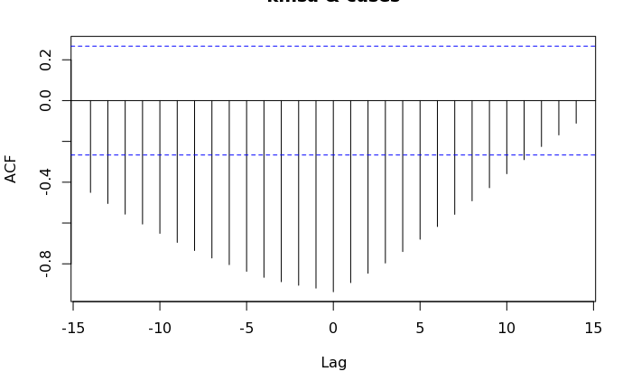

```r
ccf(kinsa, cases, plot = TRUE) #run this in the console to get a non-cutoff version of the graph
```

```r
ccf(kinsa, cases, plot = FALSE)
```

```
Autocorrelations of series ‘X’, by lag

   -14    -13    -12    -11    -10     -9     -8     -7     -6     -5     -4     -3     -2     -1      0      1      2
-0.450 -0.504 -0.556 -0.605 -0.651 -0.695 -0.735 -0.771 -0.804 -0.837 -0.866 -0.888 -0.905 -0.919 -0.937 -0.892 -0.846
     3      4      5      6      7      8      9     10     11     12     13     14
-0.796 -0.740 -0.680 -0.617 -0.557 -0.491 -0.427 -0.358 -0.289 -0.225 -0.168 -0.111
```

At a glance, we see that negative lag generally has stronger correlations than positive lag. Within a 10-day lag or shorter, observed_ili has a fairly strong negative correlation with Covid cases. Generally, this tells us that observed_ili declines a few days before Covid cases increase. To make sense of this, it’s helpful to think of observed_ili as a leading indicator for sicknesses in general (not just Covid). It might take days after someone takes their temperature with a Kinsa thermometer to be officially diagnosed with an illness, which would reflect the lag in the data.

However, it remains an open question why observed influenza-like incidences consistently decline after the initial outbreak, despite the continuing rise in Covid cases. In NYC for example, cases have risen dramatically, yet observed_ili continues to decline for some reason. Perhaps people who are already infected stop taking their temperature (with Kinsa) after being diagnosed?